# HITO 2

# 1 Lectura de datos

Vamos a cargar el conjunto de datos principal.

## 1.1 Integración

Primeramente, teníamos los vuelos separados por meses, es decir, teníamos 9 datasets distintos con los vuelos de cada mes. Para poder trabajar con un único dataframe, guardamos los datasets respectivos a cada mes, cada uno en una variable distinta, y los juntamos todos en una misma base de datos empleando la función bind_rows. Después a través de la función write.csv, pasamos este nuevo archivo de datos a formato csv para poder trabajar con él (se adjunta el fichero donde realizamos esto en la tarea):

```r
df=read.csv("C:/Users/carle/Desktop/Ciencia de datos/SEGUNDO/2n Cuatri/ProyII/VUELOS/vuelos_completo.csv")
```

# 2 Limpieza y transformación de los datos

Comenzaremos con la limpieza y tratamiento de datos. En primer lugar, diremos qué siginifica cada variable y eliminaremos aquellas variables irrelevantes para los fines de nuestro estudio.

Eliminaremos las siguientes: **X**: Se trata del índice que indica el número de fila.  
**YEAR**:Es irrelevante porque todos los vuelos son de 2023.  
**MKT_CARRIER**:Tenemos otra columna que nos da una información más específica.  
**ORIGIN_AIRPORT_SEQ_ID**:Tenemos otra columna con la misma información.  
**DEST_AIRPORT_SEQ_ID**:Tenemos otra columna con la misma información.  
**TAXI_OUT**:No nos interesa esta variable para el estudio.  
**WHEELS_OFF**:No nos interesa esta variable para el estudio.  
**MKT_CARRIER_FL_NUM**:tenemos otra variable mejor para el estudio.

```r
df=df[,!colnames(df)%in% c('X','YEAR','MKT_CARRIER', 'ORIGIN_AIRPORT_SEQ_ID','DEST_AIRPORT_SEQ_ID','TAXI_OUT', 'WHEELS_OFF','MKT_CARRIER_FL_NUM')]
```

Una vez eliminadas las variables que no íbamos a utilizar, realizamos un resumen de las variables restantes:

```r
desc_df = data.frame("variable" = colnames(df),
                      "tipo" = c( rep("categorical", 8), rep("text",2),
                                 rep("categorical",2), rep("text",2), rep("numerical", 6),
                                 "binary","categorical", "binary",
                                 rep("numerical",9)),stringsAsFactors = FALSE)
rownames(desc_df) = desc_df$variable
desc_df
```

```
##                                variable        tipo
## MONTH                             MONTH categorical
## DAY_OF_MONTH               DAY_OF_MONTH categorical
## DAY_OF_WEEK                 DAY_OF_WEEK categorical
## OP_CARRIER                   OP_CARRIER categorical
## TAIL_NUM                       TAIL_NUM categorical
## OP_CARRIER_FL_NUM     OP_CARRIER_FL_NUM categorical
## ORIGIN_AIRPORT_ID     ORIGIN_AIRPORT_ID categorical
## ORIGIN                           ORIGIN categorical
## ORIGIN_CITY_NAME       ORIGIN_CITY_NAME        text
## ORIGIN_STATE_NM         ORIGIN_STATE_NM        text
## DEST_AIRPORT_ID         DEST_AIRPORT_ID categorical
## DEST                               DEST categorical
## DEST_CITY_NAME           DEST_CITY_NAME        text
## DEST_STATE_NM             DEST_STATE_NM        text
## CRS_DEP_TIME               CRS_DEP_TIME   numerical
## DEP_TIME                       DEP_TIME   numerical
## DEP_DELAY                     DEP_DELAY   numerical
## CRS_ARR_TIME               CRS_ARR_TIME   numerical
## ARR_TIME                       ARR_TIME   numerical
## ARR_DELAY                     ARR_DELAY   numerical
## CANCELLED                     CANCELLED      binary
## CANCELLATION_CODE     CANCELLATION_CODE categorical
## DIVERTED                       DIVERTED      binary
## CRS_ELAPSED_TIME       CRS_ELAPSED_TIME   numerical
## ACTUAL_ELAPSED_TIME ACTUAL_ELAPSED_TIME   numerical
## AIR_TIME                       AIR_TIME   numerical
## DISTANCE                       DISTANCE   numerical
## CARRIER_DELAY             CARRIER_DELAY   numerical
## WEATHER_DELAY             WEATHER_DELAY   numerical
## NAS_DELAY                     NAS_DELAY   numerical
## SECURITY_DELAY           SECURITY_DELAY   numerical
## LATE_AIRCRAFT_DELAY LATE_AIRCRAFT_DELAY   numerical
```

## 2.1 Detección de valores faltantes

Es importante conocer cuantos datos faltantes tenemos en nuestra base de datos y examinar si se pueden eliminar o debemos mantenerlos. Vamos a mostrar en que columnas tenemos y cuántos hay en cada una de ellas.

```r
valores_faltantes <- colSums(is.na(df))

# Mostrar las columnas con valores faltantes y la cantidad de valores faltantes en cada una
print(valores_faltantes[valores_faltantes > 0])
```

```
##            DEP_TIME           DEP_DELAY            ARR_TIME           ARR_DELAY
##               84966               84997               89816              103481
##    CRS_ELAPSED_TIME ACTUAL_ELAPSED_TIME            AIR_TIME       CARRIER_DELAY
##                   5              103481              103481             4245463
##       WEATHER_DELAY           NAS_DELAY      SECURITY_DELAY LATE_AIRCRAFT_DELAY
##             4245463             4245463             4245463             4245463
```

Podemos observar que tenemos muchos datos faltantes, tenemos que determinar cuáles de estos se pueden eliminar y cuáles pueden ser relevantes para el estudio. Hay 103.481 filas con valores faltantes en el retraso de la hora de llegada. Investigando sobre los datos, hemos podido ver que se trata de vuelos cancelados y desviados, que no han llegado al aeropuerto de destino, por tanto, son vuelos que no nos interesan a priori en el estudio, así que podemos eliminarlos.

En cambio, las columnas **CARRIER_DELAY**,**WEATHER_DELAY**… hay muchísimos datos faltantes porque se trata del tiempo de retraso dependiendo de los distintos factores que los han podido provocar, por tanto, como son variables de interés, las dejaremos en la base de datos por si hacemos algún futuro análisis con ellas.

Vamos a realizar también una copia del dataframe actual antes de borrar por si acaso queremos usar alguna de las variables que vamos a eliminar más adelante.

```r
copia_df=df

df=subset(df,CANCELLED==0 & DIVERTED==0 & !is.na(ARR_TIME))
```

También borraremos las columnas **CANCELLED**,**CANCELLATION_CODE** y **DIVERTED** ,ya que, ahora todos los valores son los mismos.

```r
df=df[,!colnames(df)%in% c("CANCELLED","CANCELLATION_CODE","DIVERTED")]
```

## 2.2 Transformación

Ahora, procedemos a cambiar el formato de las variables que contienen información sobre las horas previstas y reales tanto de salida como de llegada. El formato será el siguiente: ‘hh:mm’.

```r
df$CRS_DEP_TIME<- ifelse(nchar(df$CRS_DEP_TIME)==3,paste0('0',df$CRS_DEP_TIME),df$CRS_DEP_TIME)
df$CRS_DEP_TIME<- ifelse(nchar(df$CRS_DEP_TIME)==2,paste0('00',df$CRS_DEP_TIME),df$CRS_DEP_TIME)
df$CRS_DEP_TIME<- ifelse(nchar(df$CRS_DEP_TIME)==1,paste0('000',df$CRS_DEP_TIME),df$CRS_DEP_TIME)
df$CRS_DEP_TIME<- strptime(df$CRS_DEP_TIME,format='%H%M')
df$CRS_DEP_TIME<-format(df$CRS_DEP_TIME, format='%H:%M')

df$DEP_TIME<- ifelse(nchar(df$DEP_TIME)==3,paste0('0',df$DEP_TIME),df$DEP_TIME)
df$DEP_TIME<- ifelse(nchar(df$DEP_TIME)==2,paste0('00',df$DEP_TIME),df$DEP_TIME)
df$DEP_TIME<- ifelse(nchar(df$DEP_TIME)==1,paste0('000',df$DEP_TIME),df$DEP_TIME)
df$DEP_TIME<- strptime(df$DEP_TIME,format='%H%M')
df$DEP_TIME<-format(df$DEP_TIME, format='%H:%M')

df$CRS_ARR_TIME<- ifelse(nchar(df$CRS_ARR_TIME)==3,paste0('0',df$CRS_ARR_TIME),df$CRS_ARR_TIME)
df$CRS_ARR_TIME<- ifelse(nchar(df$CRS_ARR_TIME)==2,paste0('00',df$CRS_ARR_TIME),df$CRS_ARR_TIME)
df$CRS_ARR_TIME<- ifelse(nchar(df$CRS_ARR_TIME)==1,paste0('000',df$CRS_ARR_TIME),df$CRS_ARR_TIME)
df$CRS_ARR_TIME<- strptime(df$CRS_ARR_TIME,format='%H%M')
df$CRS_ARR_TIME<-format(df$CRS_ARR_TIME, format='%H:%M')


df$ARR_TIME<- ifelse(nchar(df$ARR_TIME)==3,paste0('0',df$ARR_TIME),df$ARR_TIME)
df$ARR_TIME<- ifelse(nchar(df$ARR_TIME)==2,paste0('00',df$ARR_TIME),df$ARR_TIME)
df$ARR_TIME<- ifelse(nchar(df$ARR_TIME)==1,paste0('000',df$ARR_TIME),df$ARR_TIME)
df$ARR_TIME<- strptime(df$ARR_TIME,format='%H%M')
df$ARR_TIME<-format(df$ARR_TIME, format='%H:%M')
```

## 2.3 Creación de nuevas características

A continuación, a partir de las variable DEP_DELAY, que indica el tiempo de retraso o adelanto en el aeropuerto de origen, crearemos dos nuevas variables derivadas. En la primera guardaremos los valores de DEP_DELAY que se corresponden con los retrasos y en la otra los valores que se corresponden con los adelantos, ya que DEP_DELAY almacena los adelantos con números negativos y los retrasos como números positivos.

También, realizaremos el mismo proceso con la variable ARR_DELAY, que indica el tiempo de retraso o adelanto en el aeropuerto de destino.

```r
df <- df %>%
  mutate(salida_retraso = ifelse(DEP_DELAY > 0, DEP_DELAY, 0),
         salida_adelanto = ifelse(DEP_DELAY < 0, -DEP_DELAY, 0),
         llegada_retraso = ifelse(ARR_DELAY > 0, ARR_DELAY, 0),
         llegada_adelanto = ifelse(ARR_DELAY < 0, -ARR_DELAY, 0))
```

Seguidamente, vamos a añadir a nuestra base de datos una nueva columna que indica el nombre de la compañía que ha realizado el vuelo. Para ello, leemos un nuevo csv con el nombre de la compañía junto con su código. Este nuevo dataset tiene dos variables, el código de la compañia y su nombre. Como nuestro conjunto de datos principal solo cuenta con el código, utilizaremos esta tabla de datos como información adicional para completar los datos.

```r
companys="C:/Users/carle/Desktop/Ciencia de datos/SEGUNDO/2n Cuatri/ProyII/companias.csv"
df_companys=read.csv(companys)
```

Ahora, juntamos ambos datasets para añadir la columna de compañías en nuestro dataframe principal, con el código de OP_CARRIER, generando una nueva columna con el nombre de las compañías.

```r
df=merge(df,df_companys,by.x = 'OP_CARRIER', by.y = 'Code',all.x = TRUE)
colnames(df)[colnames(df)=='Description']='NOMBRE_COMP'
```

# 3 Comprendiendo nuestros datos

Antes de comenzar con el análisis exploratorio de los datos, debemos entender bien qué datos poseemos y cómo son:

Ahora, explicaremos qué significa cada observación:

```r
kable(df[1,])
```

| OP_CARRIER | MONTH | DAY_OF_MONTH | DAY_OF_WEEK | TAIL_NUM | OP_CARRIER_FL_NUM | ORIGIN_AIRPORT_ID | ORIGIN | ORIGIN_CITY_NAME | ORIGIN_STATE_NM | DEST_AIRPORT_ID | DEST | DEST_CITY_NAME | DEST_STATE_NM | CRS_DEP_TIME | DEP_TIME | DEP_DELAY | CRS_ARR_TIME | ARR_TIME | ARR_DELAY | CRS_ELAPSED_TIME | ACTUAL_ELAPSED_TIME | AIR_TIME | DISTANCE | CARRIER_DELAY | WEATHER_DELAY | NAS_DELAY | SECURITY_DELAY | LATE_AIRCRAFT_DELAY | salida_retraso | … |
| --- | --- | --- | --- | --- | --- | --- | --- | --- | --- | --- | --- | --- | --- | --- | --- | --- | --- | --- | --- | --- | --- | --- | --- | --- | --- | --- | --- | --- | --- | --- |
| 9E | 4 | 3 | 1 | N305PQ | 5070 | 12478 | JFK | New York, NY | New York | 14685 | SAV | Savannah, GA | Georgia | 09:59 | 09:52 | -7 | 12:21 | 12:10 | -11 | 142 | 138 | 103 | 718 | NA | NA | NA | NA | NA | 0 | … |

Vemos que cada fila representa un vuelo. Se indica qué avión lo realizó, la compañía encargada, los aeropuertos de origen y destino, las horas de salida y llegada, etc.

Para comprender mejor nuestros datos, realizaremos un seguimiento a un avión en concreto para que sea más fácil de leer y asimilar la información. Gracias a la variable **TAIL_NUM**, que es el número de cola, podemos identificar a cada avión. A continuación, nos centraremos en el avión con número de cola N123NN para explicar nuestros datos:

```r
numero_de_cola <- "N123NN"
#N171US
vuelos_avion <- df %>%filter(TAIL_NUM == numero_de_cola)

vuelos_avion <- vuelos_avion %>%arrange(MONTH, DAY_OF_MONTH, DEP_TIME)
```

En **vuelos_avion** tenemos todos los vuelos que realizó el avión con este número de cola ordenados por fecha cronológica ascendente. Realizó un total de 904 vuelos. Visualizamos sus 10 primeros vuelos contemplando las variables necesarias para entender los datos:

```r
kable(vuelos_avion[1:10,c(1,3,5,8,12,16,19)])
```

| OP_CARRIER | DAY_OF_MONTH | TAIL_NUM | ORIGIN | DEST | DEP_TIME | ARR_TIME |
| --- | --- | --- | --- | --- | --- | --- |
| AA | 1 | N123NN | SEA | DFW | 07:25 | 13:32 |
| AA | 1 | N123NN | DFW | SAT | 16:05 | 17:06 |
| AA | 1 | N123NN | SAT | DFW | 17:43 | 18:54 |
| AA | 1 | N123NN | DFW | RDU | 20:33 | 23:58 |
| AA | 2 | N123NN | RDU | DFW | 07:02 | 09:10 |
| AA | 2 | N123NN | DFW | PHL | 10:35 | 14:39 |
| AA | 2 | N123NN | PHL | DFW | 16:28 | 19:58 |
| AA | 2 | N123NN | DFW | JAX | 21:06 | 01:26 |
| AA | 3 | N123NN | JAX | DFW | 07:43 | 09:49 |
| AA | 3 | N123NN | DFW | PDX | 10:57 | 13:00 |

Hemos representado únicamente estas variables para observar de una forma más sintetizada la información. Si nos fijamos en los 10 primeros vuelos de este avión, nos damos cuenta como a partir del segundo vuelo, el avión va de A a B y en el siguiente vuelo va de B a A. Es decir, observamos como en el segundo vuelo va desde el aeropuerto de DFW hasta el de SAT y en el siguiente de SAT a DFW, luego va de DFW a RDU y después de RDU a DFW, etc. Por tanto, observando esto vemos que hay rutas establecidas entre aeropuertos.

Centrando nuestra atención en los tiempos de salida (**DEP_TIME**) y llegada (**ARR_TIME**), podemos ver como al llegar de un aeropuerto a otro, se dejan cierto margen a la hora de realizar el siguiente vuelo. Esta información resulta bastante útil, ya que, ningún vuelo tendrá un retraso tan sumamente grande durante su trayecto que haga que su hora de llegada al destino supere la hora de salida del siguiente vuelo programado de ese avión. Con los márgenes que dejan entre la llegada y la siguiente salida del mismo avión, se evita que se acumulen retrasos que afecten a vuelos posteriores.

```r
numero_de_cola <- "N907XJ"
#N171US
vuelos_avion <- df %>%filter(TAIL_NUM == numero_de_cola)

vuelos_avion <- vuelos_avion %>%arrange(MONTH, DAY_OF_MONTH, DEP_TIME)
kable(vuelos_avion[1:10,c(1,3,5,8,12,16,19)])
```

| OP_CARRIER | DAY_OF_MONTH | TAIL_NUM | ORIGIN | DEST | DEP_TIME | ARR_TIME |
| --- | --- | --- | --- | --- | --- | --- |
| 9E | 1 | N907XJ | ATL | HPN | 09:47 | 12:13 |
| 9E | 1 | N907XJ | HPN | ATL | 13:00 | 15:28 |
| 9E | 1 | N907XJ | ATL | TYS | 18:06 | 18:52 |
| 9E | 2 | N907XJ | TYS | DTW | 07:25 | 08:56 |
| 9E | 2 | N907XJ | DTW | MEM | 12:23 | 13:20 |
| 9E | 2 | N907XJ | MEM | DTW | 14:10 | 16:55 |
| 9E | 2 | N907XJ | DTW | RDU | 17:54 | 19:25 |
| 9E | 3 | N907XJ | RDU | JFK | 06:39 | 08:44 |
| 9E | 3 | N907XJ | JFK | SAV | 11:21 | 14:04 |
| 9E | 3 | N907XJ | SAV | JFK | 14:41 | 16:43 |

Por último, crearemos una variable derivada llamada RUTA, donde uniremos los aeropuertos ORIGEN y DESTINO, de tal manera que por ejemplo si A es el origen y B el destino, guardaremos RUTA= A-B, de tal manera que no importa cual es aeropuerto de origen, ya que en la variable RUTA, es lo mismo ir de A a B, que de B a A.

```r
df$RUTA <- ifelse(df$ORIGIN < df$DEST, paste(df$ORIGIN, df$DEST, sep = "-"), paste(df$DEST, df$ORIGIN, sep = "-"))
```

# 4 Análisis exploratorio de los datos

Ahora vamos a empezar con el análisis exploratorio de los datos. En primer lugar, vamos a realizar un gráfico de barras indicando los 10 aeropuertos con mayor número de vuelos registrados y los 10 aeropuertos con menos.Usaremos la libreria ggplot2 que ya ha sido cargada anteriormente.

En primer lugar, visualizaremos un histograma con los 10 aeropuertos que participan en menos vuelos:

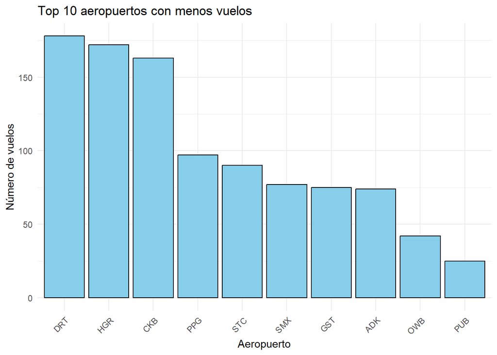

```r
bottom_10_aeropuertos <- names(tail(sort(table(df$ORIGIN), decreasing = TRUE), 10))

datos_bottom_10 <- df[df$ORIGIN %in% bottom_10_aeropuertos, ]
datos_bottom_10$ORIGIN <- factor(datos_bottom_10$ORIGIN, levels = bottom_10_aeropuertos)


ggplot(datos_bottom_10, aes(x = ORIGIN)) +
  geom_bar(fill = "skyblue", color = "black") +
  labs(x = "Aeropuerto", y = "Número de vuelos", title = "Top 10 aeropuertos con menos vuelos") +
  theme_minimal() +
  theme(axis.text.x = element_text(angle = 45, hjust = 1))
```

Podemos destacar el aeropuerto de PUB como el aeropuerto con menos vuelos de la base de datos. Podemos resaltar de estos 10 aerpuertos que ninguno ha participado en más de 200 vuelos.

A continuación, visualizaremos los 10 aeropuertos que participan en el mayor número de vuelos:

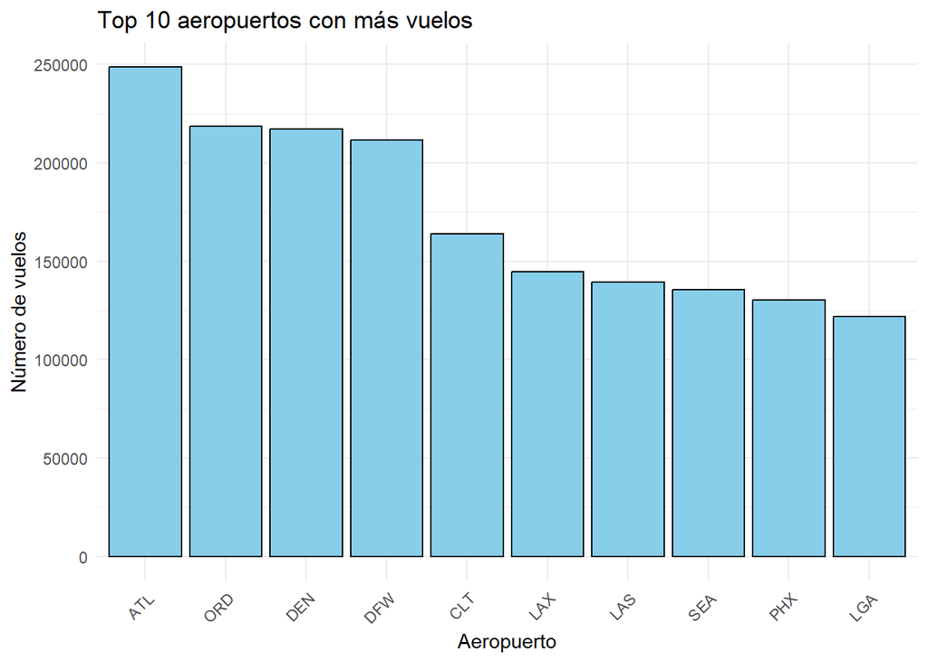

```r
top_10_aeropuertos <- names(head(sort(table(df$ORIGIN), decreasing = TRUE), 10))
datos_top_10= df[df$ORIGIN %in% top_10_aeropuertos, ]

datos_top_10$ORIGIN <- factor(datos_top_10$ORIGIN, levels = top_10_aeropuertos)


ggplot(datos_top_10, aes(x = ORIGIN)) +
  geom_bar(fill = "skyblue", color = "black") +
  labs(x = "Aeropuerto", y = "Número de vuelos", title = "Top 10 aeropuertos con más vuelos") +
  theme_minimal() +
  theme(axis.text.x = element_text(angle = 45, hjust = 1))
```

Si nos fijamos en este nuevo histograma, observamos una gran diferencia con respecto al número de vuelos de los aeropuertos anteriores, ya que, los aeropuertos de esta nueva gráfica han participado en 100000 vuelos o más.

Ahora, vamos a hacer un top 5 de las compañías con más y menos vuelos de nuestra base de datos:

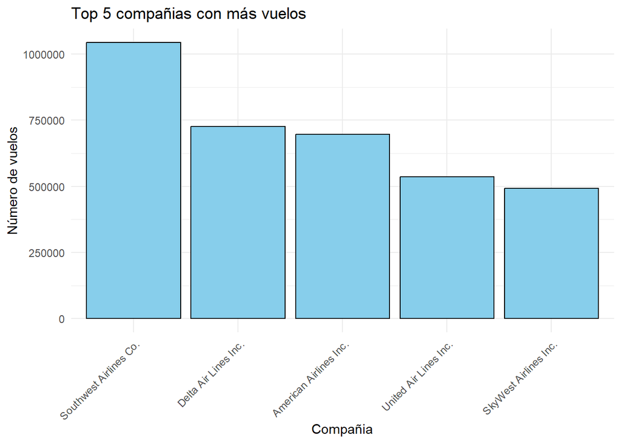

```r
top_10_companies <- names(head(sort(table(df$NOMBRE_COMP), decreasing = TRUE), 5))
datos_top_10_comp<- df[df$NOMBRE_COMP %in% top_10_companies, ]

datos_top_10_comp$ORIGIN <- factor(datos_top_10_comp$NOMBRE_COMP, levels = top_10_companies)


ggplot(datos_top_10_comp, aes(x = ORIGIN)) +
  geom_bar(fill = "skyblue", color = "black") +
  labs(x = "Compañia", y = "Número de vuelos", title = "Top 5 compañias con más vuelos") +
  theme_minimal() +
  theme(axis.text.x = element_text(angle = 45, hjust = 1))
```

Destacamos la compañía Southwest Airlines como la compañía con mayor número de vuelos, habiendo sido responsable de más de un millón de vuelos.

Visualizamos ahora las 5 compañías con menos vuelos:

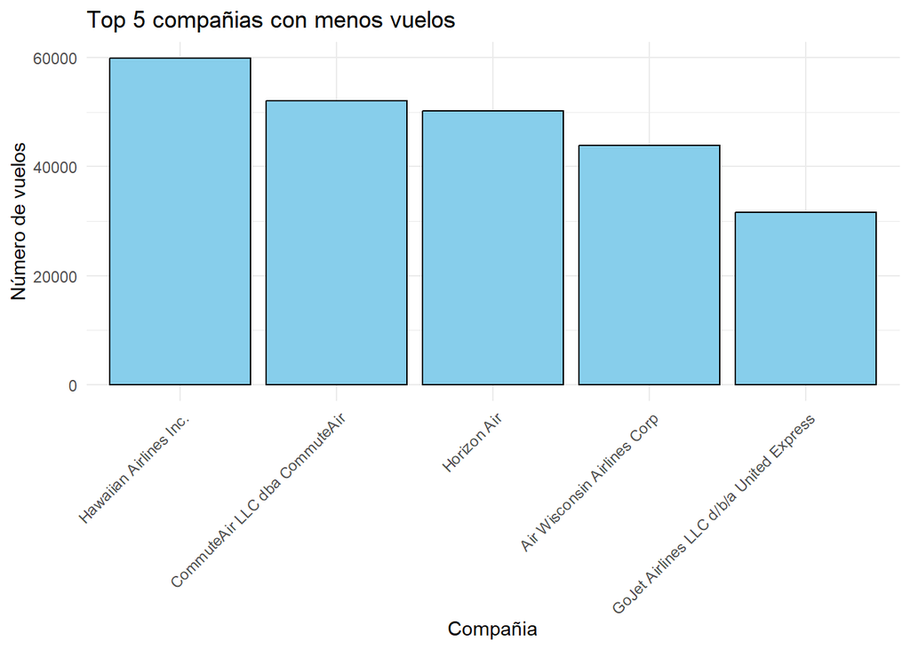

```r
bottom_10_companies <- names(tail(sort(table(df$NOMBRE_COMP), decreasing = TRUE), 5))
datos_bottom_10_comp<-df[df$NOMBRE_COMP %in% bottom_10_companies, ]

datos_bottom_10_comp$ORIGIN <- factor(datos_bottom_10_comp$NOMBRE_COMP, levels = bottom_10_companies)

ggplot(datos_bottom_10_comp, aes(x = ORIGIN)) +
  geom_bar(fill = "skyblue", color = "black") +
  labs(x = "Compañia", y = "Número de vuelos", title = "Top 5 compañias con menos vuelos") +
  theme_minimal() +
  theme(axis.text.x = element_text(angle = 45, hjust = 1))
```

Siguiendo con las compañías y los aeropuertos, realizando la función **aeropuertos_por_compañia** podremos obtener el número de aeropuertos con los que trabaja cada compañía:

```r
aeropuertos_por_compañia <- aggregate(
  ORIGIN ~ NOMBRE_COMP,
  data = df,
  FUN = function(x) c(n_distinct(x), toString(unique(x)))
)


names(aeropuertos_por_compañia) <- c("Nombre_Compañia", "Aeropuertos")

aeropuertos_por_compañia$nombre_aeroupuertos=aeropuertos_por_compañia$Aeropuertos[,2]
aeropuertos_por_compañia$num_aeropuertos=aeropuertos_por_compañia$Aeropuertos[,1]
aeropuertos_por_compañia <- subset(aeropuertos_por_compañia, select = -Aeropuertos)
aeropuertos_por_compañia$num_aeropuertos <- as.numeric(aeropuertos_por_compañia$num_aeropuertos)
```

Una vez creada, visualizamos con un histograma el número de aeropuertos por compañía utilizando la función anterior:

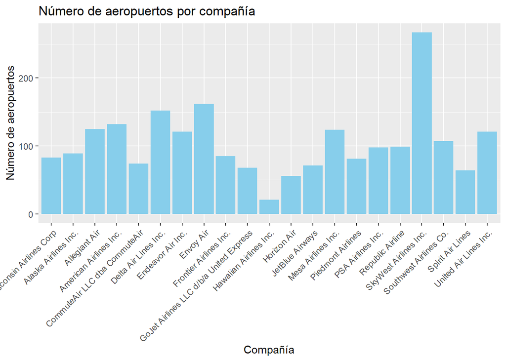

```r
ggplot(aeropuertos_por_compañia, aes(x =Nombre_Compañia, y = num_aeropuertos)) +
  geom_bar(stat = "identity", fill = "skyblue") +
  labs(title = "Número de aeropuertos por compañía",
       x = "Compañía",
       y = "Número de aeropuertos") +
  theme(axis.text.x = element_text(angle = 45, hjust = 1))
```

Representamos mediante un diagrama de tarta las 5 compañías que trabajan en más aeropuertos:

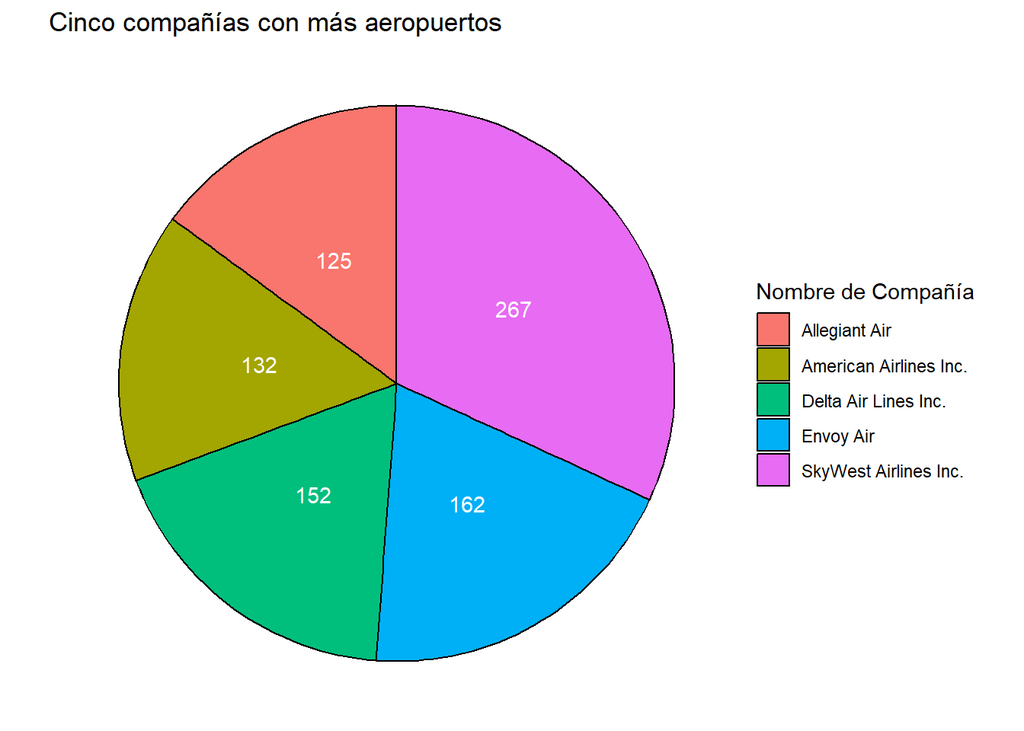

```r
aeropuertos_por_compañia <- aeropuertos_por_compañia[order(-aeropuertos_por_compañia$num_aeropuertos), ]


top_compañias <- head(aeropuertos_por_compañia, 5)

ggplot(top_compañias, aes(x = "", y = num_aeropuertos, fill = Nombre_Compañia)) +
  geom_bar(stat = "identity", width = 1,color="black") +
  geom_text(aes(label = num_aeropuertos), position = position_stack(vjust = 0.5), color = "white")+
  coord_polar("y", start = 0) +
  labs(title = "Cinco compañías con más aeropuertos",
       fill = "Nombre de Compañía",
       y = "Número de aeropuertos",
       x = "") +
  theme_void() +
  theme(legend.position = "right")
```

Por último, realizaremos una tabla que muestre para cada ruta,la media de retraso en minutos, la distancia de esa ruta y el número de vuelos que hubo en esa ruta. Ordenamos por número de vuelos y visualizamos las 5 primeras para observar cómo queda:

```r
media_retraso <- aggregate(llegada_retraso ~ RUTA, data = df, FUN = mean)



num_vuelos <- aggregate(llegada_retraso ~ RUTA, data = df, FUN = length)

dist <- aggregate(DISTANCE  ~ RUTA,data=df,FUN = mean)


resultados <- merge(merge(media_retraso, num_vuelos, by = "RUTA"), dist, by = "RUTA")


colnames(resultados) <- c("RUTA", "media_retraso", "num_vuelos","Distancia")


resultados<-resultados %>%arrange(-num_vuelos)

resultados$media_retraso <- round(resultados$media_retraso, 2)


kable(head(resultados,5))
```

| RUTA | media_retraso | num_vuelos | Distancia |
| --- | --- | --- | --- |
| HNL-OGG | 10.70 | 18835 | 100 |
| LAX-SFO | 14.90 | 17479 | 337 |
| LAS-LAX | 21.23 | 15723 | 236 |
| JFK-LAX | 22.28 | 14835 | 2475 |
| BOS-DCA | 17.18 | 14793 | 399 |